# STA 380 Part 2 Exercises Juwon Lee, Aakash Talathi, Milan Patel, Teja Sirigina

# Clustering and PCA

```r
# PCA
wine <- read_csv("wine.csv")
```

```r
library(ggplot2)
library(tidyverse)
head(wine)
```

| fixed.acidity | volatile.acidity | citric.acid | residual.sugar | chlorides | free.sulfur.dioxide | total.sulfur.dioxide | density | pH | sulphates | alcohol | quality | color |
| --- | --- | --- | --- | --- | --- | --- | --- | --- | --- | --- | --- | --- |
| 7.4 | 0.70 | 0.00 | 1.9 | 0.076 | 11 | 34 | 0.9978 | 3.51 | 0.56 | 9.4 | 5 | red |
| 7.8 | 0.88 | 0.00 | 2.6 | 0.098 | 25 | 67 | 0.9968 | 3.20 | 0.68 | 9.8 | 5 | red |
| 7.8 | 0.76 | 0.04 | 2.3 | 0.092 | 15 | 54 | 0.9970 | 3.26 | 0.65 | 9.8 | 5 | red |
| 11.2 | 0.28 | 0.56 | 1.9 | 0.075 | 17 | 60 | 0.9980 | 3.16 | 0.58 | 9.8 | 6 | red |
| 7.4 | 0.70 | 0.00 | 1.9 | 0.076 | 11 | 34 | 0.9978 | 3.51 | 0.56 | 9.4 | 5 | red |
| 7.4 | 0.66 | 0.00 | 1.8 | 0.075 | 13 | 40 | 0.9978 | 3.51 | 0.56 | 9.4 | 5 | red |

```r
Z = scale(wine[,1:12], center=TRUE, scale=FALSE)
winepca = prcomp(Z, rank=6, scale=TRUE)
summary(winepca)
```

```
## Importance of first k=6 (out of 12) components:
##                           PC1    PC2    PC3     PC4     PC5     PC6
## Standard deviation     1.7440 1.6278 1.2812 1.03374 0.91679 0.81265
## Proportion of Variance 0.2535 0.2208 0.1368 0.08905 0.07004 0.05503
## Cumulative Proportion  0.2535 0.4743 0.6111 0.70013 0.77017 0.82520
```

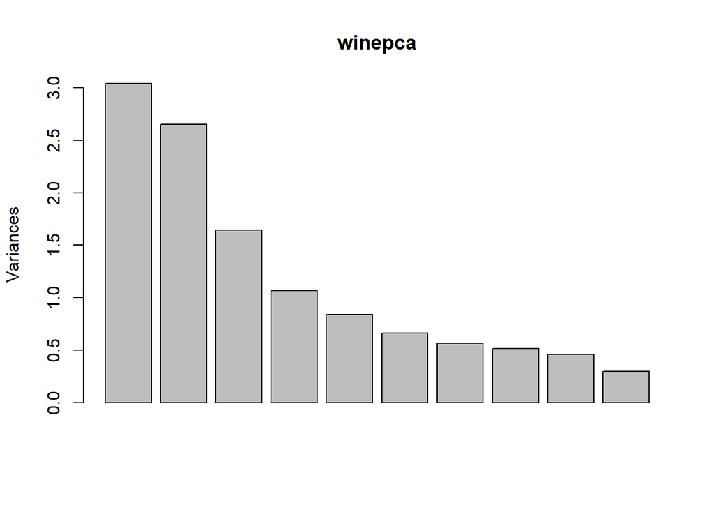

```r
plot(winepca)
```

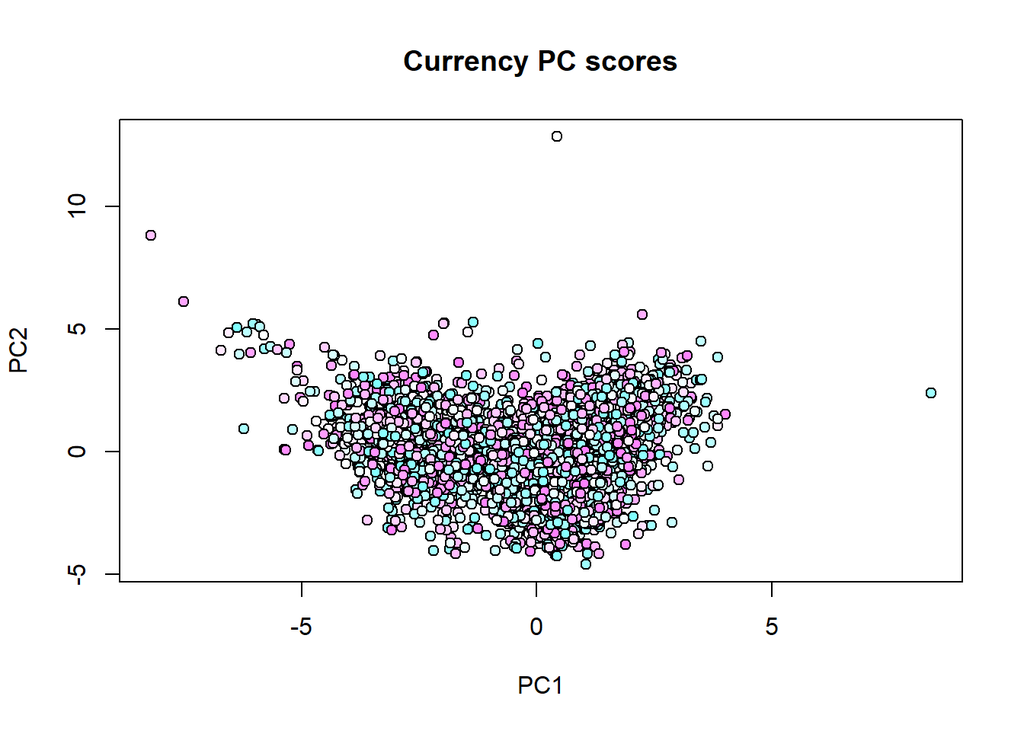

```r
scores=predict(winepca)
plot(scores[,1:2], pch=21, bg=cm.colors(120)[120:1], main="Currency PC scores")
```

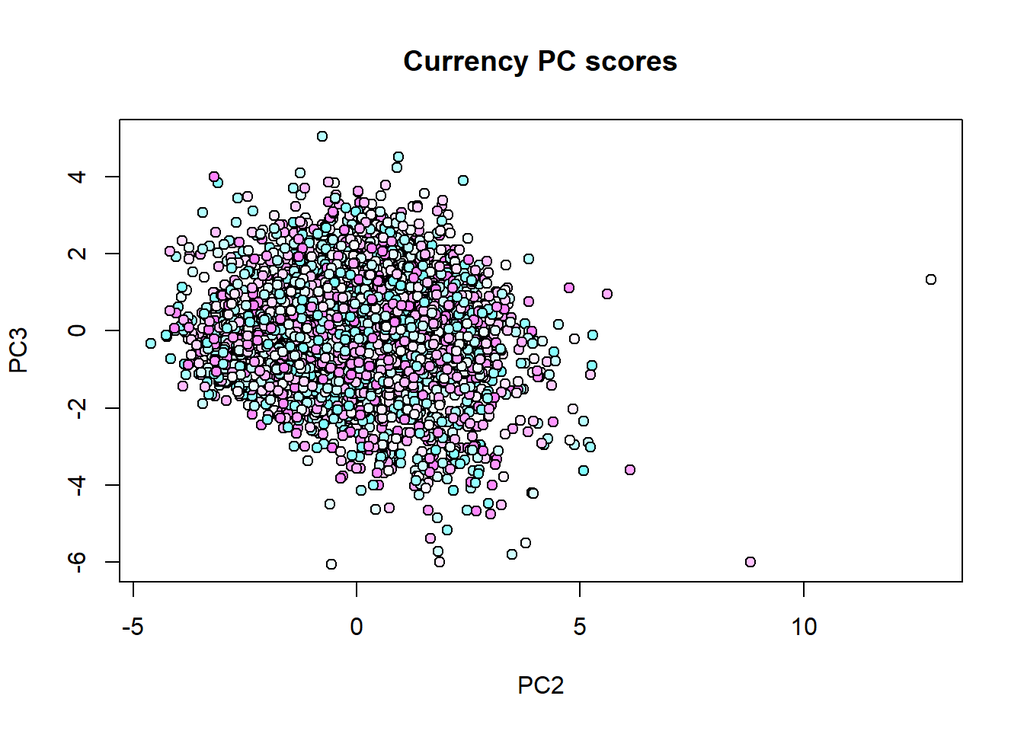

```r
plot(scores[,2:3], pch=21, bg=cm.colors (120)[120:1], main="Currency PC scores")
```

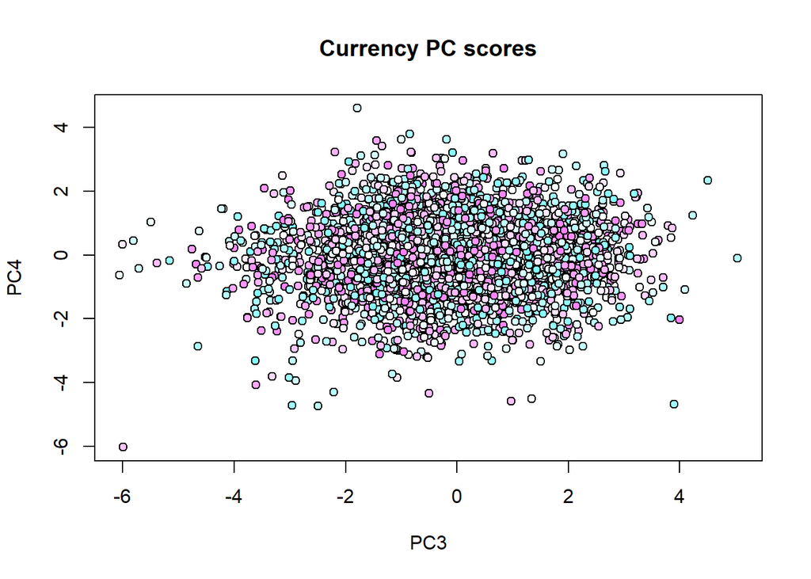

```r
plot(scores[,3:4], pch=21, bg=cm.colors(120)[120:1], main="Currency PC scores")
```

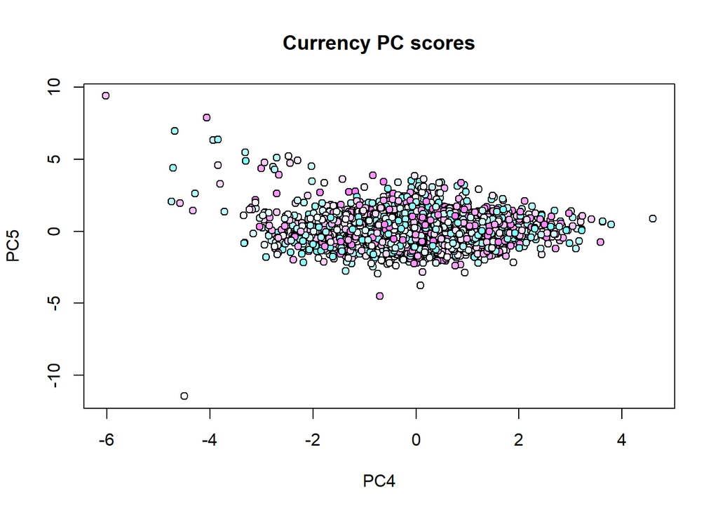

```r
plot(scores[,4:5], pch=21, bg=cm.colors(120)[120:1], main="Currency PC scores")
```

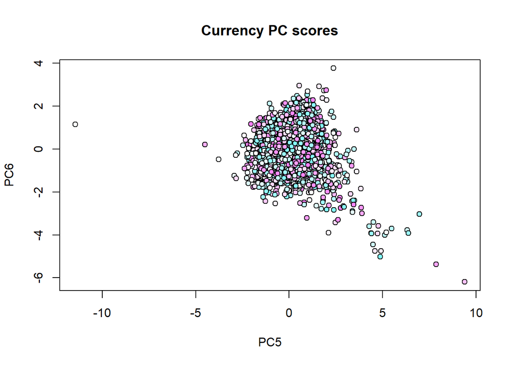

```r
plot(scores[,5:6], pch=21, bg=cm.colors(120)[120:1], main="Currency PC scores")
```

```r
# K Means Clustering:

# Loading package
library(ClusterR)
library(cluster)
```

```r
# Removing initial label of
# Species from original dataset
wine <- read_csv("wine.csv")
wine_1 <- wine[,1:12]
```

```r
# Fitting K-Means clustering Model
# to training dataset
set.seed(240) # Setting seed
kmeans.re <- kmeans(wine_1, centers = 2, nstart = 25)
kmeans.re
```

```
## K-means clustering with 2 clusters of sizes 3689, 2808
##
## Cluster means:
##   fixed.acidity volatile.acidity citric.acid residual.sugar  chlorides
## 1      6.904812        0.2871659   0.3397642       7.244809 0.04859257
## 2      7.623219        0.4086378   0.2908725       3.076425 0.06580983
##   free.sulfur.dioxide total.sulfur.dioxide   density       pH sulphates
## 1            39.75590            155.69246 0.9947903 3.190808 0.4999485
## 2            18.39868             63.26318 0.9945736 3.254882 0.5724145
##    alcohol  quality
## 1 10.25932 5.824343
## 2 10.79722 5.810541
##
## Clustering vector:
##    [1] 2 2 2 2 2 2 2 2 2 2 2 2 2 2 1 1 2 2 2 2 2 2 2 2 2 2 2 2 2 2 2 2 1 2 2 2 2
```

[output cut: 184 more lines]

```r
# Cluster identification for
# each observation
kmeans.re$cluster
```

```
##    [1] 2 2 2 2 2 2 2 2 2 2 2 2 2 2 1 1 2 2 2 2 2 2 2 2 2 2 2 2 2 2 2 2 1 2 2 2 2
##   [38] 2 2 2 2 2 2 2 2 2 1 2 2 2 2 2 2 1 2 2 2 1 2 2 2 1 2 2 2 2 2 2 2 2 2 2 2 2
##   [75] 2 2 2 2 2 1 2 2 2 2 2 2 1 2 1 2 1 1 1 2 2 2 2 2 2 2 2 2 2 2 2 2 2 2 2 1 2
##  [112] 2 2 2 2 2 2 2 2 2 2 2 2 2 2 2 2 2 2 2 1 2 2 2 2 2 2 2 2 2 2 2 2 2 2 1 2 2
##  [149] 2 2 2 2 2 2 1 1 1 1 2 2 2 2 2 1 1 2 2 2 2 2 2 2 2 2 2 2 2 2 2 2 2 2 2 2 2
##  [186] 2 2 2 1 1 1 2 1 2 2 1 2 2 2 2 2 1 2 2 2 2 2 1 2 2 2 2 2 2 2 1 2 2 2 1 2 2
##  [223] 2 2 2 2 2 2 2 2 2 2 2 2 2 2 2 2 2 2 2 2 2 2 2 2 2 2 2 2 2 2 2 2 2 1 2 2 2
##  [260] 2 2 2 2 2 2 2 2 2 2 2 2 2 2 2 2 2 2 2 2 2 2 2 2 2 2 2 2 2 2 2 2 2 2 2 2 2
##  [297] 2 2 2 2 2 2 2 2 2 2 2 2 2 2 2 2 2 1 2 2 2 2 2 2 2 2 2 2 2 2 2 2 2 2 2 2 1
##  [334] 2 2 2 2 2 2 2 2 2 2 2 2 2 2 2 2 2 2 2 2 2 1 2 2 2 2 2 2 2 2 2 2 2 2 2 2 2
##  [371] 2 2 2 2 2 2 2 2 2 2 2 2 2 2 2 2 2 2 2 2 2 2 2 2 2 2 1 2 2 2 1 2 2 2 2 2 2
##  [408] 2 2 2 2 2 2 2 1 1 2 1 2 2 2 2 2 2 2 2 2 2 2 2 2 2 2 2 2 2 2 2 2 2 2 2 2 2
##  [445] 2 2 2 2 2 2 2 2 2 2 2 2 2 2 2 2 2 2 2 1 2 2 2 2 2 2 2 2 2 2 2 2 2 2 2 2 2
##  [482] 2 2 2 2 2 2 2 2 2 2 2 2 2 2 2 2 1 2 2 2 2 2 2 2 2 2 2 2 2 2 2 2 2 2 1 2 2
##  [519] 2 2 2 2 1 1 1 2 2 2 2 2 2 2 2 2 2 2 2 2 2 2 2 2 2 2 2 2 2 2 2 2 2 2 2 2 2
```

[output cut: 161 more lines]

```r
# Confusion Matrix
cm <- table(wine$color, kmeans.re$cluster)
cm
```

```
##
##            1    2
##   red     85 1514
##   white 3604 1294
```

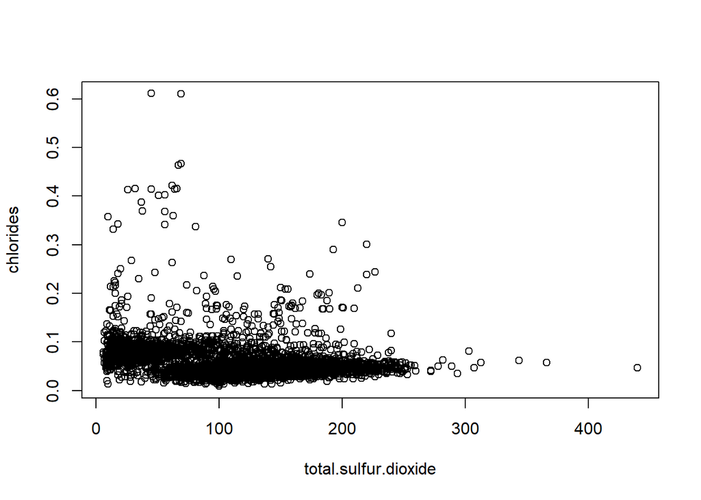

```r
# Model Evaluation and visualization
plot(wine_1[c("total.sulfur.dioxide", "chlorides")])
```

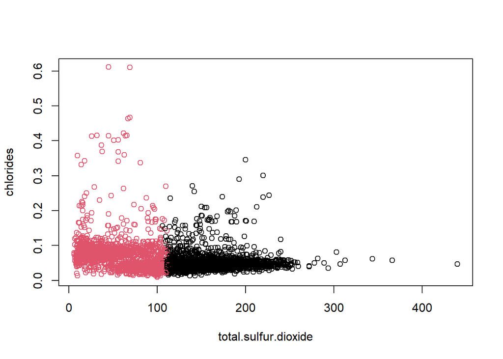

```r
plot(wine_1[c("total.sulfur.dioxide", "chlorides")],
     col = kmeans.re$cluster)
```

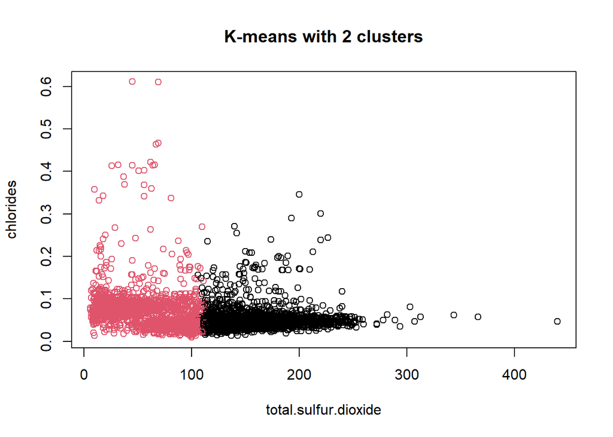

```r
plot(wine_1[c("total.sulfur.dioxide", "chlorides")],
     col = kmeans.re$cluster,
     main = "K-means with 2 clusters")
```

```r
## Plotiing cluster centers
kmeans.re$centers
```

```
##   fixed.acidity volatile.acidity citric.acid residual.sugar  chlorides
## 1      6.904812        0.2871659   0.3397642       7.244809 0.04859257
## 2      7.623219        0.4086378   0.2908725       3.076425 0.06580983
##   free.sulfur.dioxide total.sulfur.dioxide   density       pH sulphates
## 1            39.75590            155.69246 0.9947903 3.190808 0.4999485
## 2            18.39868             63.26318 0.9945736 3.254882 0.5724145
##    alcohol  quality
## 1 10.25932 5.824343
## 2 10.79722 5.810541
```

```r
kmeans.re$centers[, c("total.sulfur.dioxide", "chlorides")]
```

```
##   total.sulfur.dioxide  chlorides
## 1            155.69246 0.04859257
## 2             63.26318 0.06580983
```

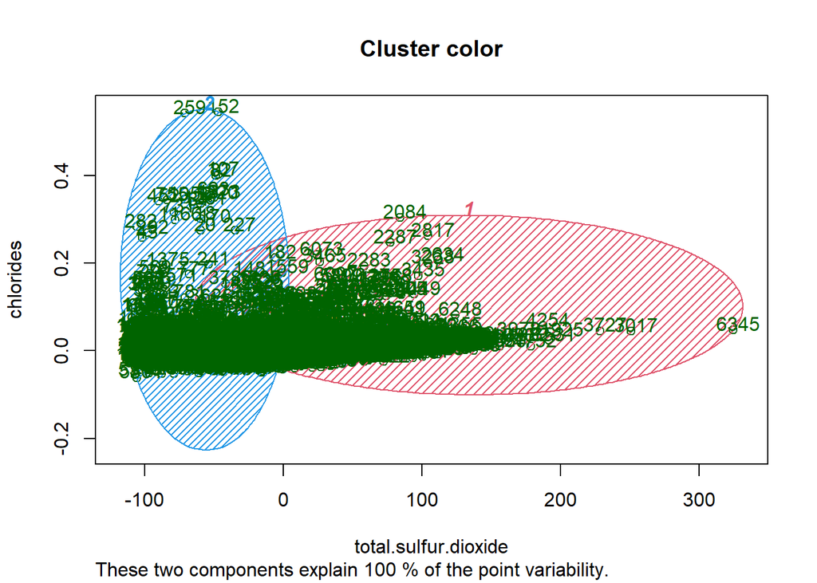

```r
## Visualizing clusters
y_kmeans <- kmeans.re$cluster
clusplot(wine_1[, c("total.sulfur.dioxide", "chlorides")],
         y_kmeans,
         lines = 0,
         shade = TRUE,
         color = TRUE,
         labels = 2,
         plotchar = FALSE,
         span = TRUE,
         main = paste("Cluster color"),
         xlab = 'total.sulfur.dioxide',
         ylab = 'chlorides')
```

# Market segmentation

```r
library(readr)
df1 <- read_csv("social_marketing.csv")
```

```
## * `` -> ...1
```

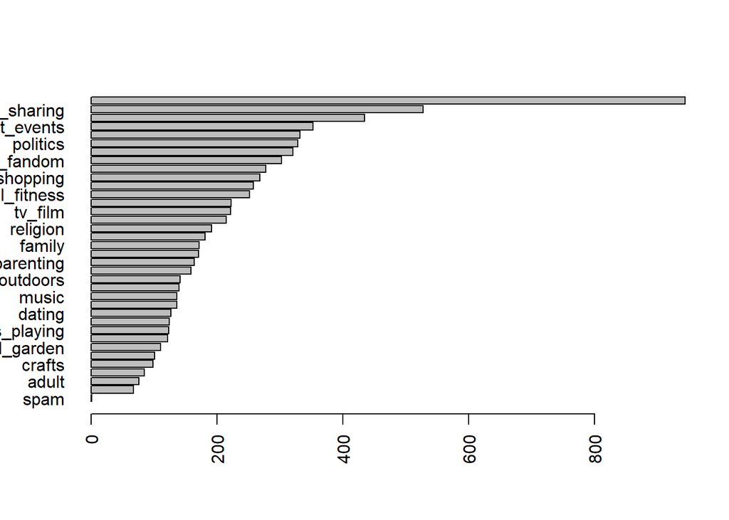

```r
#View(df)
library(dplyr)
df2 = select(df1, -1) #gets rid of user ids
df3 <- df2 %>%
  mutate(across(, ~ .x / rowSums(across()))) #normalizing
colsums = sort(colSums(df3))
barplot(colsums, horiz=TRUE, las=2)
```

```r
#same thing that milan did but instead of just sum, its the normalized sum

library("ggpubr")
```

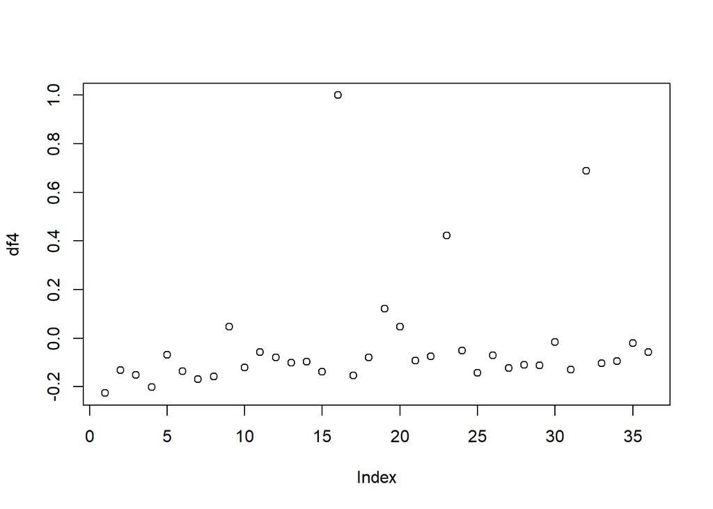

```r
df3correlations <- cor(df3[,])
df4 <- select(as.data.frame(df3correlations), 16) #<- variable index number
plot.default(df4)
```

```r
#df3 is the correlation df that includes the correlations between all the data,
#df4 is just health_nutrition's correlation. This variable index can be changed as fit
```

# The Reuters corpus

```r
# raw.files <- data_frame(filename = list.files('/Users/aakashtalathi/Desktop/ReutersC50/C50train'))
#
#
# raw.file.paths <- raw.files  %>%
# mutate(filepath = paste0("/Users/aakashtalathi/Desktop/ReutersC50/C50train/", filename))
#
# for (x in raw.file.paths)
# {
#   q = x
#   raw.files.x <- data_frame(filenamex = list.files(x))
# }
# View(raw.files.x)
```

We had trouble loading in the raw files for this question so I wrote a brief analysis of the process we would have gone through had we successfully loaded them in. Rather then looking at individual texts of an author we believed it to be more benifical to group together each text as one large paragraph which is representative of the words the author would use. As we did not have a way to easily measure sentiment for this dataset we decided to calulate the IDF scores for each unique word used by the author, and this data would be what we would cluster on. This allows us to get a representation of how unique a authors vocabulary is as compared to their peers. Based on the results of clustering, we may be able to see groups of authors with similar vocabulary levels/usuage.

The question that will be answered in this analysis is what authors have similar unique vocabulary levels to each other? The approach that will be used is calculating the average of the TF-IDF of all words unique words an author uses. For example, if a an author uses the word “it” multiple times it will only be counted ones in terms of the TF-IDF. Essentially, we are creating a list of every unique word an author has ever used in the given texts and running the TF-IDF over every list of authors. We then calculate the average TF-IDF score per author. Using this technique we can hope to see a scatterplot of each author, grouped together with other authors with similar unique vocabulary words. If an author tends to use words that other authors do not, we will see them clustered together and vice versa. We believe that two or three clusters is the optimal level for this problem as there should not be micro clusters within the vocabulary levels of the authors.

In conclusion this analysis is important because it presents an mathematical grouping of authors who may be using more unique words, an indicator that they are writing about topics others aren’’t or using a wider range of vocabulary which may be indicative of certain writing features.

# Association rule mining

```r
# install.packages("arules")
# install.packages("arulesViz")

library(tidyverse)
library(igraph)
library(arules)  # has a big ecosystem of packages built around it
library(arulesViz)
data("Groceries")

rules <- apriori(Groceries, parameter=list(support=.02, confidence=.15))
```

```
## Apriori
##
## Parameter specification:
##  confidence minval smax arem  aval originalSupport maxtime support minlen
##        0.15    0.1    1 none FALSE            TRUE       5    0.02      1
##  maxlen target  ext
##      10  rules TRUE
##
## Algorithmic control:
##  filter tree heap memopt load sort verbose
##     0.1 TRUE TRUE  FALSE TRUE    2    TRUE
##
## Absolute minimum support count: 196
##
## set item appearances ...[0 item(s)] done [0.00s].
## set transactions ...[169 item(s), 9835 transaction(s)] done [0.01s].
## sorting and recoding items ... [59 item(s)] done [0.00s].
## creating transaction tree ... done [0.01s].
## checking subsets of size 1 2 3 done [0.00s].
## writing ... [93 rule(s)] done [0.00s].
## creating S4 object  ... done [0.00s].
```

```r
arules::inspect(rules[1:20])
```

```
##      lhs                        rhs                support    confidence
## [1]  {}                      => {soda}             0.17437722 0.1743772
## [2]  {}                      => {rolls/buns}       0.18393493 0.1839349
## [3]  {}                      => {other vegetables} 0.19349263 0.1934926
## [4]  {}                      => {whole milk}       0.25551601 0.2555160
## [5]  {frozen vegetables}     => {whole milk}       0.02043721 0.4249471
## [6]  {beef}                  => {whole milk}       0.02125064 0.4050388
## [7]  {curd}                  => {whole milk}       0.02613116 0.4904580
## [8]  {pork}                  => {other vegetables} 0.02165735 0.3756614
## [9]  {pork}                  => {whole milk}       0.02216573 0.3844797
## [10] {frankfurter}           => {whole milk}       0.02053889 0.3482759
## [11] {bottled beer}          => {whole milk}       0.02043721 0.2537879
## [12] {brown bread}           => {whole milk}       0.02521607 0.3887147
## [13] {margarine}             => {whole milk}       0.02419929 0.4131944
## [14] {butter}                => {other vegetables} 0.02003050 0.3614679
```

[output cut: 27 more lines]

What our association rules tell us is that people buy soda, rolls/buns, other vegetables, and whole milk the most. This is why we can assume with nothing else in their basket, they would get these items. Whole milk seems to be something people get frequently regardless of other items as many association rules are recommending whole milk. Some interesting rules to be seen are pork and other vegetables as typically you would combine both in a dish. However, for other proteins such as beef, the first recommendation remains as whole milk. Butter can be an association to begetables as people tend to cook vegetables in butter.

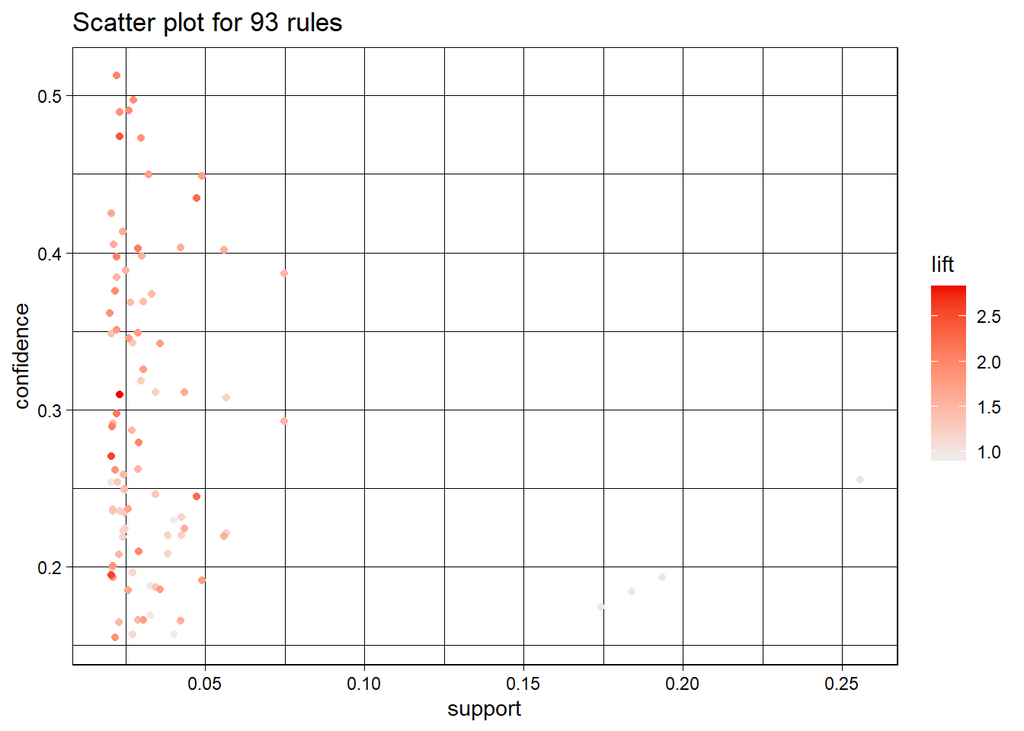

```r
plot(rules)
```

Overall, high lift gives us low support (although everything is pretty low on support)